# Awr1642-oob-non-os Users Guide

## 5.3 Running the Binary

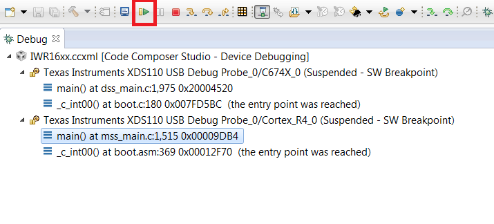

- With both executables loaded, select mss_main.c, as shown, and press the **Run/Resume** button

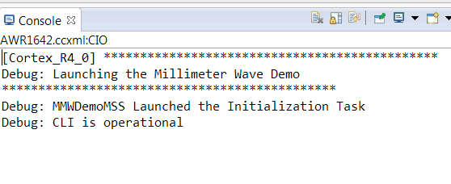

- The program should start executing and generate console output as shown.

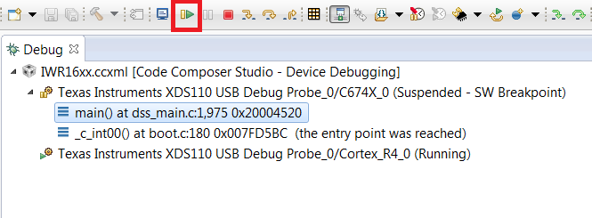

- Select dss_main.c, as shown, and press the **Run/Resume** button

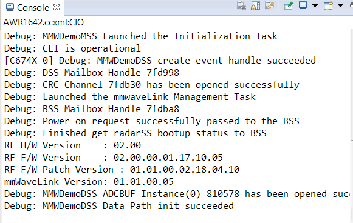

- Further console output should be generated as shown.
- You should see the “CLI is operational” message which indicates that the program is ready and waiting for the sensor configuration.

The sensor configuration is sent using the web GUI

## 5.4 Running the Lab GUI

- Using Google Chrome, navigate to the following URL: https://dev.ti.com/mmWaveDemoVisualizer
  - Alternatively, go to https://dev.ti.com/gallery and search for “mmWave Demo Visualizer”
- If prompted, follow the on-screen instructions for installing [TI Cloud Agent](https://software-dl.ti.com/ccs/esd/documents/ti_cloud_agent.html)
- Once the demo is loaded, go to **Options → Serial Port**
- In the serial port window, enter the appropriate port in each of the drop down menus based on your port numbers from Step 2.

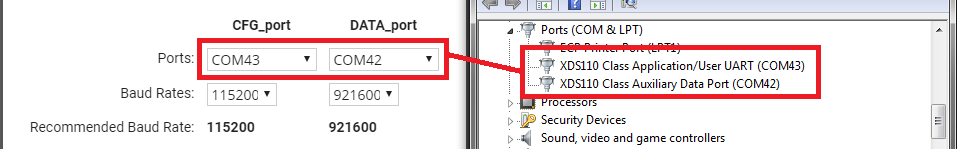

- Click on **Configure** and the demo will automatically connect to the EVM

```
* If the connection fails, try clicking on the connection icon in the bottom left corner
```

- Select the appropriate mmWave device from the **Platform** dropdown menu
- Use the available options to create the desired configuration
  - Additional details about the configuration parameters can be found in the [**mmWave Demo Visualizer User Guide**](https://www.ti.com/lit/ug/swru529c/swru529)
- When ready to send the configuration, click on **Send Config To mmWave Device**
- Click on the **Plots** tab to view the plots that were selected to be shown
- Move a highly reflective object in front of the EVM and see how the demo responds

[figure not shown]

# Learn more about TI mmWave Sensors

Learn more about xWR1x devices, please visit the product pages:

- AWR1443
- AWR1642
- AWR1843

Get started evaluating the platform with xWR1x EVMs, purchase EVM at:

- [AWR1443 EVM](http://www.ti.com/tool/AWR1443BOOST)
- [AWR1642 EVM](http://www.ti.com/tool/AWR1642BOOST)
- [AWR1843 EVM](http://www.ti.com/tool/AWR1843BOOST)

Download [mmWave SDK](http://www.ti.com/tool/MMWAVE-SDK)  
Ask question on TI’s [E2E forum](http://e2e.ti.com)